# Von Mises Mixture Model Tutorial: Understanding and Implementing the EM Algorithm

1. Introduction
2. Understanding Circular Data
3. Understanding the Von Mises Distribution
4. Why Mixture Models for Circular Data?
5. The Von Mises Mixture Model Class
6. Understanding the EM Algorithm
7. Working with Real Data
8. Analysis and Interpretation
9. Concluding Remarks

## Introduction

In this tutorial, we'll explore the von Mises mixture model and implement the Expectation-Maximization (EM) algorithm to fit circular data. This approach is particularly valuable for analyzing angular data, where standard linear statistics are inappropriate due to the circular nature of the measurements.

This tutorial focuses on:

- Understanding what makes circular data unique and how to properly analyze it
- Implementing the von Mises distribution for circular data analysis
- Using mixture models to identify multiple patterns or strategies in angular data
- Applying the EM algorithm to fit von Mises mixture models
- Interpreting the results from practical applications

Let's start by importing the necessary libraries:

```python
import numpy as np
import matplotlib.pyplot as plt
import pandas as pd
from scipy.stats import vonmises
import seaborn as sns
```

## Understanding Circular Data

### What is Circular Data?

Circular data refers to measurements taken on a circular scale, where the beginning and end of the measurement range connect seamlessly. Common examples include:

- **Directional data**: Wind directions, animal movement headings, compass bearings
- **Temporal data with cyclical patterns**: Time of day, day of week, seasonal patterns
- **Angular measurements**: Joint angles in biomechanics, phase angles in signal processing
- **Orientational data**: Molecular orientations, crystal structures

### What Makes Circular Data Special?

Circular data requires special statistical treatment because:

1. **Wrap-around property**: 0° and 360° represent the same direction, creating a circular topology where the scale "wraps around" itself
2. **No natural zero**: There's often no natural origin or reference point
3. **Bounded range**: Values typically lie in a bounded interval (e.g., [0°, 360°] or [-π, π])
4. **Discontinuity issue**: The numerical representation has an artificial discontinuity (e.g., the jump from 359° to 0°)

## Understanding the Von Mises Distribution

The von Mises distribution is the circular analog of the normal distribution, specifically designed for angular data. It's characterized by two parameters:

- μ (mu): the mean direction (in radians)
- κ (kappa): the concentration parameter (higher values = more concentrated)

Let's visualize the von Mises distribution for different values of μ and κ:

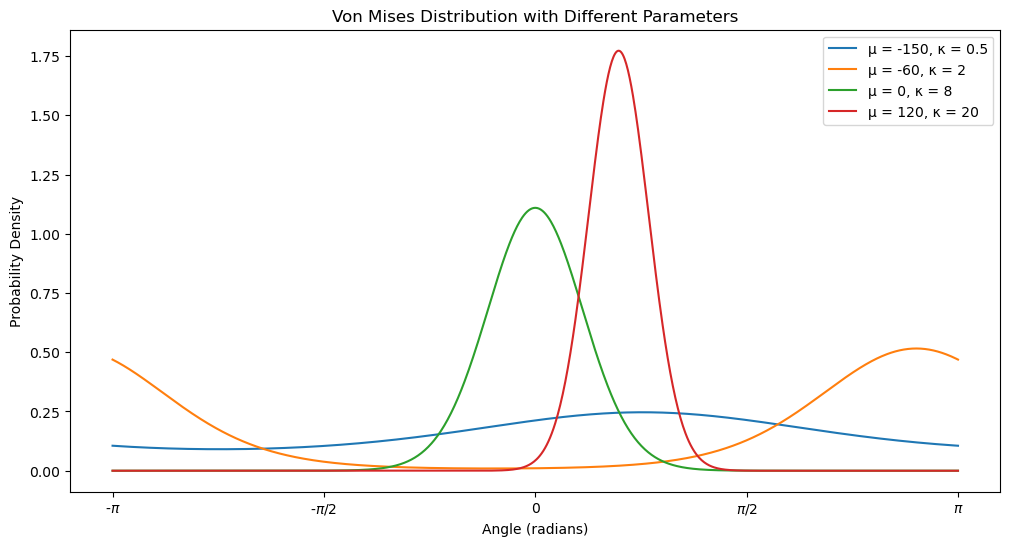

```python
def plot_vonmises_distributions():
    # Create a range of angles from -π to π
    x = np.linspace(-np.pi, np.pi, 1000)

    # Try different concentration values
    mus = [-150, -60, 0, 120]
    kappas = [0.5, 2, 8, 20]

    # Plot for each kappa
    plt.figure(figsize=(12, 6))
    for i in range(len(mus)):
        y = vonmises.pdf(x, kappas[i], loc=mus[i])
        plt.plot(x, y, label=f'μ = {mus[i]}, κ = {kappas[i]}')

    # Customize the plot
    plt.xlabel('Angle (radians)')
    plt.ylabel('Probability Density')
    plt.title('Von Mises Distribution with Different Parameters')
    plt.xticks([-np.pi, -np.pi/2, 0, np.pi/2, np.pi],
               [r'-$\pi$', r'-$\pi/2$', '0', r'$\pi/2$', r'$\pi$'])
    plt.legend()
    plt.show()

plot_vonmises_distributions()
```

### Key Properties of the Von Mises Distribution

- **The von Mises concentration parameter κ** is analogous to the precision of a Gaussian (1/σ²), so increasing κ makes the circular density more sharply peaked (lower circular variance), whereas increasing the Gaussian standard deviation σ makes its bell curve flatter and more dispersed.
- **The von Mises mean direction μ** defines exactly where the circular distribution is centered on the circle, just as the Gaussian mean μ centers its bell curve on the real line.
- **Periodic domain**: Because the von Mises density lives on a 2π-periodic domain, the curve "wraps around" without breaks, fully capturing the continuity of angular data.

## Why Mixture Models for Circular Data?

In many real-world scenarios, circular data might have multiple modes or clusters. For example, when studying animal movement directions, we might observe different preferred directions. A single von Mises distribution cannot capture this multimodality, which is where mixture models come in.

A von Mises mixture model combines multiple von Mises distributions, each with its own parameters (μ, κ) and weight. The probability density function is:

$$p(\theta) = \sum_{i=1}^{k} w_i f(\theta; \mu_i, \kappa_i) + w_0 \frac{1}{2\pi}$$

Where:

- $f(\theta; \mu_i, \kappa_i)$ is the von Mises PDF
- $w_i$ is the weight of component $i$
- $w_0$ is the weight of an optional uniform component

Let's visualize what a mixture model looks like:

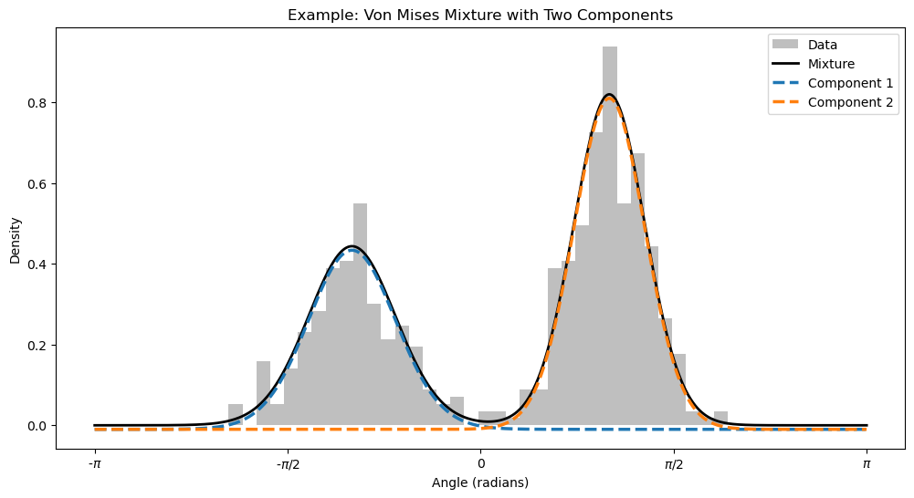

```python
def generate_mixture_example():
    # Generate synthetic data from a mixture of two von Mises distributions
    n_samples = 500

    # Define the mixture parameters
    means = [-np.pi/3, np.pi/3]  # Component means
    kappas = [8, 12]             # Component concentrations
    weights = [0.4, 0.6]         # Component weights

    # Generate random samples
    samples = np.empty(n_samples)

    # Determine which component each sample belongs to
    component_indicators = np.random.choice(2, size=n_samples, p=weights)

    # Generate samples from each component
    for i in range(n_samples):
        component = component_indicators[i]
        samples[i] = np.random.vonmises(means[component], kappas[component])

    # Plot the histogram and true distributions
    plt.figure(figsize=(12, 6))

    # Histogram of samples
    plt.hist(samples, bins=36, density=True, alpha=0.5, label='Data', color='gray')

    # Plot the true mixture distribution
    x = np.linspace(-np.pi, np.pi, 1000)
    y_mixture = np.zeros_like(x)

    for i in range(2):
        y_component = vonmises.pdf(x, kappas[i], loc=means[i])*weights[i]
        y_mixture += y_component

    plt.plot(x, y_mixture, 'k-', linewidth=2, label='Mixture')

    for i in range(2):
        y_component = vonmises.pdf(x, kappas[i], loc=means[i])*weights[i]
        # push it down for a little bit for visibility
        plt.plot(x, y_component-0.01, '--', label=f'Component {i+1}', linewidth=2.5)


    plt.title('Example: Von Mises Mixture with Two Components')
    plt.xlabel('Angle (radians)')
    plt.ylabel('Density')
    plt.xticks([-np.pi, -np.pi/2, 0, np.pi/2, np.pi],
               [r'-$\pi$', r'-$\pi/2$', '0', r'$\pi/2$', r'$\pi$'])
    plt.legend()
    plt.show()

    return samples

# Generate and visualize a mixture example
mixture_data = generate_mixture_example()
```

- An example for mixture von Mises distribution with to components centering around -π/3 and π/3, with concentrations 8 and 12.

## The Von Mises Mixture Model Class

Now, let's implement the von Mises mixture model class. This class will handle the parameter estimation using the EM algorithm and provide methods for model selection and visualization.

```python
class VonMisesMixture:
    """
    Simplified implementation of von Mises mixture models for circular data analysis.
    Uses EM algorithm with optional uniform noise component.
    """

    def __init__(self, min_components=2, max_components=10,
                 min_kappa=0.5, max_kappa=100.0,
                 use_uniform_noise=True,
                 n_restarts=50, max_iter=1000,
                 tol=1e-7, min_angle_sep_deg=10):
        """
        Initialize the von Mises mixture model.

        Parameters:
        -----------
        min_components : int
            Minimum number of components to try
        max_components : int
            Maximum number of components to try
        min_kappa : float
            Minimum concentration parameter
        max_kappa : float
            Maximum concentration parameter
        use_uniform_noise : bool
            Whether to include a uniform noise component
        n_restarts : int
            Number of random restarts for optimization
        max_iter : int
            Maximum number of iterations for optimization
        tol : float
            Convergence tolerance
        min_angle_sep_deg : float
            Minimum separation between component means in degrees
        """
        self.min_components = min_components
        self.max_components = max_components
        self.min_kappa = min_kappa
        self.max_kappa = max_kappa
        self.use_uniform_noise = use_uniform_noise
        self.n_restarts = n_restarts
        self.max_iter = max_iter
        self.tol = tol
        self.min_angle_sep_deg = min_angle_sep_deg

        # Will store fitting results
        self.best_params = None
        self.best_n_components = None
        self.best_bic = float('inf')  # Changed to use standard BIC where lower is better
        self.all_results = None
        self.uniform_weight = 0.0 if use_uniform_noise else None
        self.is_fitted = False

    def _check_means_separation(self, means, min_angle_deg=None):
        """
        Check if the von Mises component means are adequately separated.

        Parameters:
        -----------
        means : array-like
            Array of component means in radians
        min_angle_deg : float or None
            Minimum separation in degrees. If None, uses self.min_angle_sep_deg

        Returns:
        --------
        bool
            True if means are adequately separated, False otherwise
        """
        if min_angle_deg is None:
            min_angle_deg = self.min_angle_sep_deg

        means_deg = np.rad2deg(means)
        means_deg = np.sort(means_deg)
        diffs = np.diff(means_deg)
        # Handle circular distance between last and first component
        diffs = np.append(diffs, 360 - (means_deg[-1] - means_deg[0]))
        return np.all(diffs >= min_angle_deg)

    def _calculate_bic(self, n_components, log_likelihood, n_samples):
        """
        Calculate the Bayesian Information Criterion (BIC).

        Parameters:
        -----------
        n_components : int
            Number of components in the model
        log_likelihood : float
            Log-likelihood of the model
        n_samples : int
            Number of data points

        Returns:
        --------
        float
            BIC score (lower is better)
        """
        # For each von Mises component: mean (1) + kappa (1) + weight (1)
        # Total von Mises parameters: n_components * 3
        # Weight parameters are subject to sum-to-one constraint, so subtract 1
        # If uniform noise is used, add 1 parameter
        n_parameters = n_components * 3 - 1
        if self.use_uniform_noise:
            n_parameters += 1

        # Standard BIC formula (lower is better)
        return n_parameters * np.log(n_samples) - 2 * log_likelihood

    def _fit_em_single(self, data, n_components):
        """
        Fit a von Mises mixture model using the EM algorithm from a single random start.

        Parameters:
        -----------
        data : array-like
            Angular data in radians
        n_components : int
            Number of components to fit

        Returns:
        --------
        tuple or None
            (weights, means, kappas, uniform_weight, log_likelihood) or None if fitting failed
        """
        n_samples = len(data)

        # Random initialization
        means = np.random.uniform(-np.pi, np.pi, size=n_components)
        kappas = np.random.uniform(self.min_kappa, self.max_kappa / 2, size=n_components)
        weights = np.random.dirichlet([1] * n_components)

        if self.use_uniform_noise:
            uniform_weight = np.random.uniform(0, 0.1)
            # Normalize weights
            total_weight = weights.sum() + uniform_weight
            weights = weights / total_weight
            uniform_weight = uniform_weight / total_weight
        else:
            uniform_weight = 0.0

        log_likelihoods = []
        log_likelihood_old = None

        for _ in range(self.max_iter):
            # E-step: Calculate responsibilities
            resp_von_mises = np.zeros((n_samples, n_components))
            for k in range(n_components):
                resp_von_mises[:, k] = weights[k] * vonmises.pdf(data, kappas[k], loc=means[k])

            if self.use_uniform_noise:
                resp_uniform = uniform_weight * (1.0 / (2.0 * np.pi))
                resp_sum = resp_von_mises.sum(axis=1) + resp_uniform

                # Responsibilities
                gamma_von_mises = resp_von_mises / resp_sum[:, np.newaxis]
                gamma_uniform = resp_uniform / resp_sum
            else:
                resp_sum = resp_von_mises.sum(axis=1)
                gamma_von_mises = resp_von_mises / resp_sum[:, np.newaxis]

            # M-step: Update parameters
            Nk = gamma_von_mises.sum(axis=0)

            if self.use_uniform_noise:
                N_uniform = gamma_uniform.sum()
                weights = Nk / n_samples
                uniform_weight = N_uniform / n_samples
            else:
                weights = Nk / n_samples
```

```python
            abandon = False
            for k in range(n_components):
                # Update means
                Ck = np.sum(gamma_von_mises[:, k] * np.cos(data))
                Sk = np.sum(gamma_von_mises[:, k] * np.sin(data))
                means[k] = np.arctan2(Sk, Ck) % (2 * np.pi)

                # Update kappas using mean resultant length
                R = np.sqrt(Ck**2 + Sk**2) / Nk[k] if Nk[k] > 0 else 0.0

                if R < 1e-8:
                    kappas[k] = self.min_kappa
                else:
                    # Approximation formulas for kappa based on R
                    if R < 0.53:
                        kappa_guess = 2 * R + R**3 + (5 * R**5) / 6
                    elif R < 0.85:
                        kappa_guess = -0.4 + 1.39 * R + 0.43 / (1 - R)
                    else:
                        kappa_guess = 1 / (R**3 - 4 * R**2 + 3 * R)

                    kappas[k] = max(kappa_guess, self.min_kappa)
                    kappas[k] = min(kappas[k], self.max_kappa)

                # Check if concentration is too small or too large
                if kappas[k] == self.min_kappa or kappas[k] == self.max_kappa:
                    abandon = True
                    break

            if abandon:
                return None

            # Calculate log-likelihood
            log_likelihood = np.sum(np.log(resp_sum))
            log_likelihoods.append(log_likelihood)

            # Check convergence
            if log_likelihood_old is not None and abs(log_likelihood - log_likelihood_old) < self.tol:
                break

            log_likelihood_old = log_likelihood

        if not log_likelihoods:
            return None

        # Check if means are adequately separated and weights are significant
        if (min(weights) > 0.01 and
            self._check_means_separation(means) and
            (not self.use_uniform_noise or uniform_weight < 0.3)):

            # Make sure weights sum to 1 (within floating point precision)
            if self.use_uniform_noise:
                total = weights.sum() + uniform_weight
                weights = weights / total
                uniform_weight = uniform_weight / total
            else:
                weights = weights / weights.sum()

            return weights, means, kappas, uniform_weight, log_likelihoods[-1]
        else:
            return None

    def fit(self, data):
        """
        Fit the von Mises mixture model to data, trying different numbers of components.

        Parameters:
        -----------
        data : array-like
            Angular data in radians

        Returns:
        --------
        self
            The fitted model
        """
        if not isinstance(data, np.ndarray):
            data = np.array(data)

        data_rad = data.copy()
        n_samples = len(data_rad)

        self.best_bic = float('inf')  # Lower is better for standard BIC
        self.best_params = None
        self.best_n_components = 0
        self.all_results = []

        for n_components in range(self.min_components, self.max_components + 1):
            print(f"Fitting model with {n_components} components...")

            best_model_for_n = None
            best_log_likelihood_for_n = -np.inf

            for restart in range(self.n_restarts):
                result = self._fit_em_single(data_rad, n_components)

                if result is None:
                    continue

                weights, means, kappas, uniform_weight, log_likelihood = result

                if log_likelihood > best_log_likelihood_for_n:
                    best_log_likelihood_for_n = log_likelihood
                    best_model_for_n = (weights, means, kappas, uniform_weight)

            if best_model_for_n is None:
                print(f"No valid models found for {n_components} components")
                continue

            weights, means, kappas, uniform_weight = best_model_for_n

            # Calculate BIC (lower is better)
            bic = self._calculate_bic(n_components, best_log_likelihood_for_n, n_samples)

            # Store this result
            self.all_results.append({
                'n_components': n_components,
                'weights': weights,
                'means': means,
                'kappas': kappas,
                'uniform_weight': uniform_weight,
                'log_likelihood': best_log_likelihood_for_n,
                'bic': bic
            })

            # Update best model based on BIC (lower is better)
            if bic < self.best_bic:
                self.best_bic = bic
                self.best_params = (weights, means, kappas)
                self.best_n_components = n_components
                self.uniform_weight = uniform_weight

        # Sort results by BIC (lower is better)
        if self.all_results:
            self.all_results.sort(key=lambda x: x['bic'])

            # Print model comparison results
            print("\nModel Comparison Results:")
            print("-" * 60)
            print(f"{'Components':<12}{'BIC':<15}{'Log-likelihood':<15}")
            print("-" * 60)
            for result in self.all_results:
                print(f"{result['n_components']:<12}{result['bic']:<15.2f}{result['log_likelihood']:<15.2f}")

        self.is_fitted = True if self.best_params is not None else False

        return self

    def plot(self, data_rad, solution_angle=60, hist_color='k', show=True,
             save_path=None, title="Von Mises Mixture Model Fit"):
        """
        Plot the fitted model.

        Parameters:
        -----------
        data_rad : array-like
            Original data in radians
        solution_angle : float
            Solution angle in degrees to mark with a vertical line
        hist_color : str
            Color for histogram
        show : bool
            Whether to show the plot
        save_path : str or None
            Path to save the figure, or None to not save
        title : str
            Plot title
```

```python
        Returns:
        --------
        fig, ax
            Figure and axes objects
        """
        if not self.is_fitted:
            raise ValueError("Model has not been fitted yet. Call fit() first.")

        weights, means, kappas = self.best_params

        # Plot results
        fig, ax = plt.subplots(figsize=(10, 6), dpi=100)

        # Explicitly turn off the grid
        ax.grid(False)

        # Plot histogram of data
        ax.hist(data_rad, bins=72, density=True, alpha=0.2, color=hist_color,
                label='Data', edgecolor='white')

        # Create x range in radians with more points for smoother curves
        x_rad = np.linspace(-np.pi, np.pi, 500)

        # Plot mixture with improved styling
        y_mixture = np.zeros_like(x_rad)
        for i in range(len(weights)):
            mu = means[i]
            kappa = kappas[i]
            weight = weights[i]
            y_mixture += weight * vonmises.pdf(x_rad, kappa, loc=mu)

        if self.use_uniform_noise and self.uniform_weight > 0:
            y_mixture += self.uniform_weight * (1.0 / (2.0 * np.pi))

        ax.plot(x_rad, y_mixture, '-', color='k', linewidth=2,
                label=f'Mixture Fit ({self.best_n_components} components)')

        # Add vertical line at solution angle
        solution_rad = np.deg2rad(solution_angle)
        ax.axvline(x=solution_rad, color='tab:green', linestyle='-', linewidth=2,
                  label=f'Solution ({solution_angle}°)')

        # Find components closest to 0° and the solution
        target_angles = [0, solution_angle]  # in degrees
        target_angles_rad = np.deg2rad(target_angles)
        closest_indices = {}

        for target in target_angles_rad:
            distances = []
            for i in range(self.best_n_components):
                mu = means[i]
                # Handle circular distance
                dist = np.abs(np.arctan2(np.sin(mu - target), np.cos(mu - target)))
                distances.append(dist)
            closest_indices[target] = np.argmin(distances)

        # Define color mapping for special components
        component_colors = {
            'zero': 'tab:red',      # Color for component closest to 0°
            'solution': 'tab:green',  # Color for component closest to solution
            'other': [
                '#1f77b4',  # blue
                '#ff7f0e',  # orange
                '#9467bd',  # purple
                '#8c564b',  # brown
                '#e377c2',  # pink
                '#7f7f7f',  # gray
                '#bcbd22',  # olive
                '#17becf',  # cyan
                '#aec7e8',  # light blue
                '#ffbb78',  # light orange
            ]
        }

        # Plot components
        other_color_idx = 0
        for i in range(self.best_n_components):
            mu = means[i]
            kappa = kappas[i]
            weight = weights[i]

            y_component = weight * vonmises.pdf(x_rad, kappa, loc=mu)

            # Choose color based on whether this component is closest to 0° or solution
            if i == closest_indices[target_angles_rad[0]]:  # closest to 0°
                color = component_colors['zero']
            elif i == closest_indices[target_angles_rad[1]]:  # closest to solution
                color = component_colors['solution']
            else:
                # Use other colors from the palette
                color = component_colors['other'][other_color_idx]
                other_color_idx = (other_color_idx + 1) % len(component_colors['other'])

            # Format the mu display in degrees
            mu_deg = np.rad2deg(mu)
            if mu_deg > 180:
                mu_deg -= 360
            elif mu_deg < -180:
                mu_deg += 360

            ax.plot(x_rad, y_component, '--', color=color, alpha=0.8, linewidth=2,
                    label=f'μ={mu_deg:.1f}°, κ={kappa:.1f}, w={weight:.3f}')

        # Add uniform component if used
        if self.use_uniform_noise and self.uniform_weight > 0:
            uniform_height = self.uniform_weight * (1.0 / (2.0 * np.pi))
            ax.axhline(y=uniform_height, color='gray', linestyle='--', linewidth=2,
                      label=f'Uniform: w={self.uniform_weight:.3f}')

        # Axis labels and styling
        ax.set_xlabel('Angle (°)', fontsize=14)
        ax.set_ylabel('Density', fontsize=14)
        ax.set_title(title, fontsize=16)
        ax.set_ylim(bottom=0)

        # Set x-axis ticks in degrees
        ax.set_xticks(np.arange(-np.pi, np.pi+0.01, np.pi/3))
        ax.set_xticklabels(np.arange(-180, 181, 60).astype(int), fontsize=12)
        ax.tick_params(axis='y', labelsize=12)

        # Remove top and right spines
        ax.spines['top'].set_visible(False)
        ax.spines['right'].set_visible(False)

        # Add legend
        ax.legend(fontsize=10, frameon=False)

        plt.tight_layout()

        if save_path:
            plt.savefig(save_path, dpi=300, bbox_inches="tight")

        if show:
            plt.show()

        return fig, ax

    def get_parameters(self):
        """
        Get the parameters of the best-fitting model.

        Returns:
        --------
        dict
            Dictionary with model parameters
        """
        if not self.is_fitted:
            raise ValueError("Model has not been fitted yet. Call fit() first.")

        weights, means, kappas = self.best_params

        # Convert means to degrees and ensure they're in [-180, 180]
        means_deg = np.rad2deg(means)
        means_deg = np.where(means_deg > 180, means_deg - 360, means_deg)
        means_deg = np.where(means_deg < -180, means_deg + 360, means_deg)

        return {
            'n_components': self.best_n_components,
            'weights': weights,
            'means_rad': means,
            'means_deg': means_deg,
            'kappas': kappas,
            'uniform_weight': self.uniform_weight,
            'bic': self.best_bic
        }

# Helper functions from the provided code
def extract_data_for_fitting(df, column='Modified Hand Angle (b)',
                           start=30, end=60,
                           late_exclude=False, baseline_exclude=False):
    """
    Extract and preprocess angular data for fitting.
```

```python
    Parameters:
    -----------
    df : pandas DataFrame
        DataFrame containing the data
    column : str
        Column name for angle data
    start : int
        Start index for data extraction
    end : int
        End index for data extraction
    late_exclude : bool
        Whether to exclude data within 1 SD of late adaptation mean
    baseline_exclude : bool
        Whether to exclude data within 1 SD of baseline mean

    Returns:
    --------
    numpy.ndarray
        Processed angle data in degrees
    """
    # Get late adaptation data if needed
    if late_exclude:
        late_data = np.vstack([dat[150:150+(end-start)] for dat in df[column].values]).flatten()
        late_mean, late_std = np.mean(late_data), np.std(late_data)

    # Get baseline data if needed
    if baseline_exclude:
        baseline_data = np.vstack([dat[:(end-start)] for dat in df[column].values]).flatten()
        baseline_mean, baseline_std = np.mean(baseline_data), np.std(baseline_data)

    # Extract main data
    if end:
        data = np.vstack([dat[start:end] for dat in df[column].values]).flatten()
    else:
        data = np.vstack([dat[start:start+30] for dat in df[column].values]).flatten()

    # Apply exclusions if requested
    sd_threshold = 1
    if baseline_exclude:
        data = data[(data > baseline_mean + sd_threshold * baseline_std) |
                   (data < baseline_mean - sd_threshold * baseline_std)]
    if late_exclude:
        data = data[(data > late_mean + sd_threshold * late_std) |
                   (data < late_mean - sd_threshold * late_std)]

    return data
```

The most important functions to pay attention to are `fit` and `_fit_em_single`.

- The `fit` function tries different numbers of components (from `min_components` to `max_components`). For each number of components, it performs multiple fitting attempts (up to `self.n_restarts`) with different random starting points.
- The `_fit_em_single` function implements the actual EM algorithm for a single starting point, iterating up to `self.max_iter` times or until convergence to find the best parameters.
- After trying all configurations, `fit` selects the best model according to the Bayesian Information Criterion (BIC).

## Understanding the EM Algorithm

The Expectation-Maximization (EM) algorithm is an iterative method for finding maximum likelihood estimates of parameters in models with latent variables. In our case, the latent variables are the component assignments for each data point.

### What Happens in the `_fit_em_single` Method?

This method is the core of our implementation, performing the EM algorithm for a von Mises mixture model. Let's break it down:

1. **Initialization**:
   - Random starting values for means, concentration parameters (kappas), and weights
   - Optional uniform component for noise
2. **E-Step (Expectation)**:
   - For each data point, calculate the probability it belongs to each component
   - These probabilities are called "responsibilities"
   - For each point i and component k: γ(i,k) = w_k × f(θ_i; μ_k, κ_k) / Σ_j w_j × f(θ_i; μ_j, κ_j)
3. **M-Step (Maximization)**:
   - Update component weights based on the sum of responsibilities
   - Update mean directions using circular statistics (arctangent of weighted sines/cosines)
   - Update concentration parameters using approximation formulas based on mean resultant length
4. **Convergence check**:
   - Calculate the log-likelihood of the data given current parameters
   - Check if the change in log-likelihood is below the tolerance threshold
5. **Model validation**:
   - Ensure component means are adequately separated
   - Ensure component weights are significant (not too small)
   - If using uniform noise, ensure it's not dominating the model

Let's visualize the responsibilities to better understand what they represent:

### The E-Step (Expectation)

In the E-step, we calculate the "responsibilities" - the probability that each data point belongs to each component of the mixture.

```python
# E-step: Calculate responsibilities
np.random.seed(42)
n_samples = 200
means = [-np.pi/3, np.pi/3]
kappas = [8, 12]
weights = [0.4, 0.6]
n_components = len(means)

component_indicators = np.random.choice(2, size=n_samples, p=weights)
data = np.array([np.random.vonmises(means[i], kappas[i]) for i in component_indicators])

resp_von_mises = np.zeros((n_samples, n_components))
for k in range(n_components):
    resp_von_mises[:, k] = weights[k] * vonmises.pdf(data, kappas[k], loc=means[k])

resp_sum = resp_von_mises.sum(axis=1)
gamma_von_mises = resp_von_mises / resp_sum[:, np.newaxis]
```

Let's visualize the responsibilities to better understand what they represent:

```python
def visualize_responsibilities(data, means, kappas, weights, uniform_weight=0):
    n_components = len(means)
    n_samples = len(data)

    # Calculate responsibilities
    resp_von_mises = np.zeros((n_samples, n_components))
    for k in range(n_components):
        resp_von_mises[:, k] = weights[k] * vonmises.pdf(data, kappas[k], loc=means[k])

    if uniform_weight > 0:
        resp_uniform = uniform_weight * (1.0 / (2.0 * np.pi))
        resp_sum = resp_von_mises.sum(axis=1) + resp_uniform
        gamma_von_mises = resp_von_mises / resp_sum[:, np.newaxis]
        gamma_uniform = resp_uniform / resp_sum
    else:
        resp_sum = resp_von_mises.sum(axis=1)
        gamma_von_mises = resp_von_mises / resp_sum[:, np.newaxis]

    # Sort data and responsibilities by angle for better visualization
    sorted_indices = np.argsort(data)
    sorted_data = data[sorted_indices]
    sorted_resp = gamma_von_mises[sorted_indices]

    # Plot
    plt.figure(figsize=(12, 8))

    # Plot data points
    plt.subplot(211)
    plt.hist(data, bins=36, density=True, alpha=0.5)

    # Plot components
    x = np.linspace(-np.pi, np.pi, 1000)
    for k in range(n_components):
        y = weights[k] * vonmises.pdf(x, kappas[k], loc=means[k])
        plt.plot(x, y, '--', label=f'Component {k+1}')

    # Plot mixture
    y_mixture = np.zeros_like(x)
    for k in range(n_components):
        y_mixture += weights[k] * vonmises.pdf(x, kappas[k], loc=means[k])
    if uniform_weight > 0:
        y_mixture += uniform_weight * (1.0 / (2.0 * np.pi))
    plt.plot(x, y_mixture, 'k-', linewidth=2, label='Mixture')

    plt.title('Data and Mixture Components')
    plt.xlabel('Angle (radians)')
    plt.ylabel('Density')
    plt.legend()

    # Plot responsibilities
    plt.subplot(212)
    for k in range(n_components):
        plt.plot(sorted_data, sorted_resp[:, k], label=f'Component {k+1}')

    if uniform_weight > 0:
        plt.plot(sorted_data, gamma_uniform[sorted_indices], label='Uniform')

    plt.title('Component Responsibilities')
    plt.xlabel('Angle (radians)')
    plt.ylabel('Responsibility (probability)')
    plt.ylim(0, 1.05)
    plt.legend()

    plt.tight_layout()
    plt.show()
```

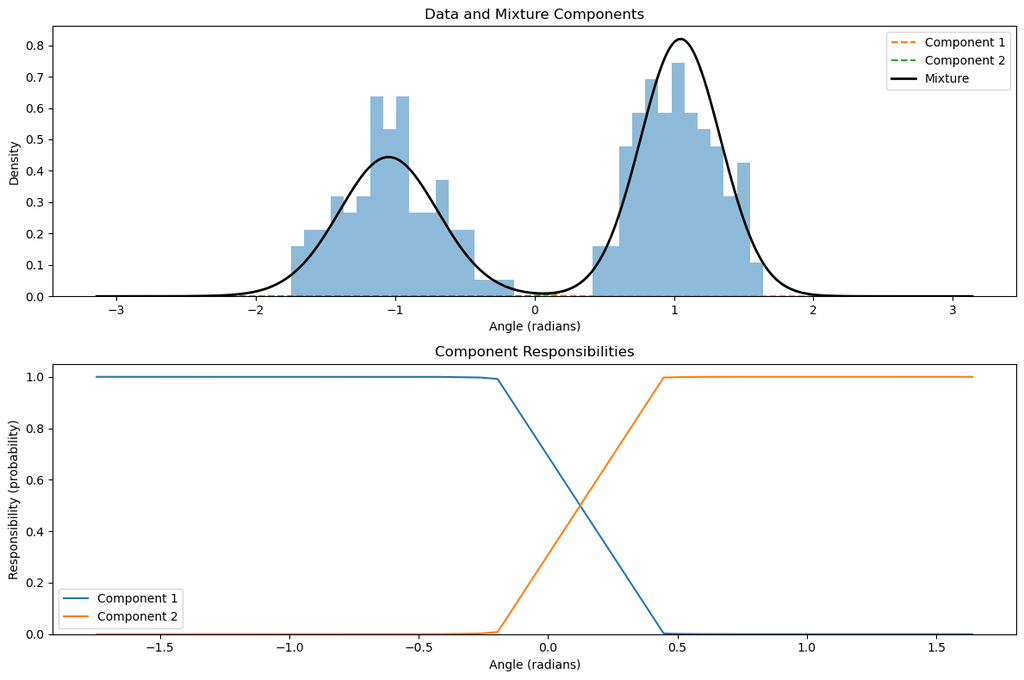

```python
# Visualize responsibilities
visualize_responsibilities(data, means, kappas, weights)
```

### The M-Step (Maximization)

In the M-step, we update the model parameters (weights, means, and kappas) based on the responsibilities calculated in the E-step.

```python
# M-step: Update parameters
Nk = gamma_von_mises.sum(axis=0)

weights = Nk / n_samples

for k in range(n_components):
    # Update means
    Ck = np.sum(gamma_von_mises[:, k] * np.cos(data))
    Sk = np.sum(gamma_von_mises[:, k] * np.sin(data))
    means[k] = np.arctan2(Sk, Ck) % (2 * np.pi)

    # Update kappas using mean resultant length
    R = np.sqrt(Ck**2 + Sk**2) / Nk[k] if Nk[k] > 0 else 0.0

    if R < 1e-8:
        kappas[k] = 0.5
    else:
        # Approximation formulas for kappa based on R
        if R < 0.53:
            kappa_guess = 2 * R + R**3 + (5 * R**5) / 6
        elif R < 0.85:
            kappa_guess = -0.4 + 1.39 * R + 0.43 / (1 - R)
        else:
            kappa_guess = 1 / (R**3 - 4 * R**2 + 3 * R)

        kappas[k] = max(kappa_guess, 0.5)
        kappas[k] = min(kappas[k], 100)
```

Let's create a function that demonstrates the EM algorithm in action:

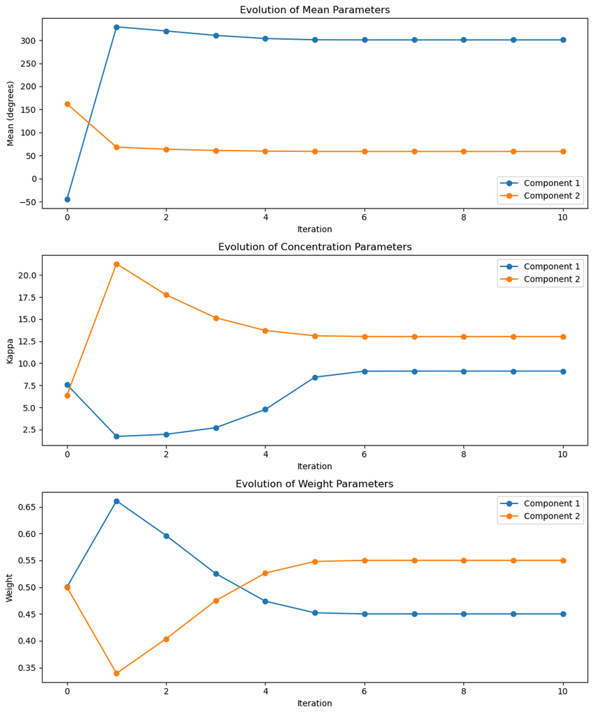

```
(array([5.25143116, 1.02739281]),
 array([ 9.11420921, 13.02687204]),
 array([0.44998466, 0.55001534]),
 0.0)
```

```python
def demonstrate_em_algorithm(data, n_components=2, max_iter=10, use_uniform=False):
    """Demonstrate the EM algorithm steps for a von Mises mixture model."""
    n_samples = len(data)

    # Initialize parameters
    np.random.seed(42)  # For reproducibility
    means = np.random.uniform(-np.pi, np.pi, size=n_components)
    kappas = np.random.uniform(1, 10, size=n_components)
    weights = np.random.dirichlet([1] * n_components)

    if use_uniform:
        uniform_weight = 0.1
        total_weight = weights.sum() + uniform_weight
        weights = weights / total_weight
        uniform_weight = uniform_weight / total_weight
    else:
        uniform_weight = 0.0

    # Store parameters for visualization
    all_means = [means.copy()]
    all_kappas = [kappas.copy()]
    all_weights = [weights.copy()]
    all_uniform_weights = [uniform_weight]

    # Run EM algorithm
    for iteration in range(max_iter):
        # E-step: Calculate responsibilities
        resp_von_mises = np.zeros((n_samples, n_components))
        for k in range(n_components):
            resp_von_mises[:, k] = weights[k] * vonmises.pdf(data, kappas[k], loc=means[k])

        if use_uniform:
            resp_uniform = uniform_weight * (1.0 / (2.0 * np.pi))
            resp_sum = resp_von_mises.sum(axis=1) + resp_uniform
            gamma_von_mises = resp_von_mises / resp_sum[:, np.newaxis]
            gamma_uniform = resp_uniform / resp_sum
        else:
            resp_sum = resp_von_mises.sum(axis=1)
            gamma_von_mises = resp_von_mises / resp_sum[:, np.newaxis]

        # M-step: Update parameters
        Nk = gamma_von_mises.sum(axis=0)

        if use_uniform:
            N_uniform = gamma_uniform.sum()
            weights = Nk / n_samples
            uniform_weight = N_uniform / n_samples
        else:
            weights = Nk / n_samples

        for k in range(n_components):
            # Update means
            Ck = np.sum(gamma_von_mises[:, k] * np.cos(data))
            Sk = np.sum(gamma_von_mises[:, k] * np.sin(data))
            means[k] = np.arctan2(Sk, Ck) % (2 * np.pi)

            # Update kappas using mean resultant length
            R = np.sqrt(Ck**2 + Sk**2) / Nk[k] if Nk[k] > 0 else 0.0

            if R < 1e-8:
                kappas[k] = 0.5
            else:
                # Approximation formulas for kappa based on R
                if R < 0.53:
                    kappa_guess = 2 * R + R**3 + (5 * R**5) / 6
                elif R < 0.85:
                    kappa_guess = -0.4 + 1.39 * R + 0.43 / (1 - R)
                else:
                    kappa_guess = 1 / (R**3 - 4 * R**2 + 3 * R)

                kappas[k] = max(kappa_guess, 0.5)
                kappas[k] = min(kappas[k], 100.0)

        # Store updated parameters
        all_means.append(means.copy())
        all_kappas.append(kappas.copy())
        all_weights.append(weights.copy())
        all_uniform_weights.append(uniform_weight)

    # Visualize the evolution of parameters
    fig, axes = plt.subplots(3, 1, figsize=(10, 12))

    # Plot means evolution
    for k in range(n_components):
        k_means = [np.rad2deg(m[k]) for m in all_means]
        axes[0].plot(range(max_iter + 1), k_means, 'o-', label=f'Component {k+1}')
    axes[0].set_title('Evolution of Mean Parameters')
    axes[0].set_xlabel('Iteration')
    axes[0].set_ylabel('Mean (degrees)')
    axes[0].legend()

    # Plot kappas evolution
    for k in range(n_components):
        k_kappas = [kk[k] for kk in all_kappas]
        axes[1].plot(range(max_iter + 1), k_kappas, 'o-', label=f'Component {k+1}')
    axes[1].set_title('Evolution of Concentration Parameters')
    axes[1].set_xlabel('Iteration')
    axes[1].set_ylabel('Kappa')
    axes[1].legend()

    # Plot weights evolution
    for k in range(n_components):
        k_weights = [w[k] for w in all_weights]
        axes[2].plot(range(max_iter + 1), k_weights, 'o-', label=f'Component {k+1}')
    if use_uniform:
        axes[2].plot(range(max_iter + 1), all_uniform_weights, 'o-', label='Uniform')
    axes[2].set_title('Evolution of Weight Parameters')
    axes[2].set_xlabel('Iteration')
    axes[2].set_ylabel('Weight')
    axes[2].legend()

    plt.tight_layout()
    plt.show()

    # Return the final model
    return means, kappas, weights, uniform_weight

# Demonstrate EM algorithm
demonstrate_em_algorithm(data)
```

You can see how the estimated parameter values converage to the real parameter values throughout each iteration!

## Working with Real Data

Now, let's create a complete example of how to use the von Mises mixture model with real-world data. This dataset comes from a visuomotor rotation task in my project, where participants' hand angles were recorded as they reached toward targets. In this task, a rotation is applied to the visual feedback—so if a participant reaches straight toward the target (0°), the cursor appears 60° off (-60°). To compensate, they must aim 60° in the opposite direction (60°) to land the cursor on the target.

```python
dat = pd.read_csv('sens_gng_learner_df.csv')
dat = dat.groupby('Subject ID').agg(list).reset_index()
dat.head(3)
```

|  | Subject ID | Trial Number | Target Angle | Hand Angle | Modified Hand Angle | RT | MT | Search Time | Group Type | Rotation Size | Modified Hand Angle with Direction | Modified Hand Angle (b) | RT (b) | Feedback Type | Group Type with Direction | Generalization |
| --- | --- | --- | --- | --- | --- | --- | --- | --- | --- | --- | --- | --- | --- | --- | --- | --- |
| 0 | 2202 | [1, 2, 3, 4, 5, 6, 7, 8, 9, 10, 11, 12, 13, 14... | [30, 270, 150, 270, 150, 30, 150, 30, 270, 150... | [26, 262, 151, 271, 147, 24, 144, 25, 269, 136... | [4.0, 8.0, -1.0, -1.0, 3.0, 6.0, 6.0, 5.0, 1.0... | [0.66, 0.988, 0.862, 0.665, 0.739, 0.758, 0.63... | [133, 103, 181, 132, 218, 135, 221, 121, 183, ... | [1634, 1451, 1380, 1647, 1349, 1403, 1625, 184... | [60, 60, 60, 60, 60, 60, 60, 60, 60, 60, 60, 6... | [60, 60, 60, 60, 60, 60, 60, 60, 60, 60, 60, 6... | [-4, -8, 1, 1, -3, -6, -6, -5, -1, -14, 3, -1,... | [-0.4333333333333335, 3.5666666666666664, -5.4... | [0.0384666666666667, 0.3664666666666667, 0.240... | [Sensory, Sensory, Sensory, Sensory, Sensory, ... | [60, 60, 60, 60, 60, 60, 60, 60, 60, 60, 60, 6... | [False, False, False, False, False, False, Fal... |
| 1 | 2208 | [1, 2, 3, 4, 5, 6, 7, 8, 9, 10, 11, 12, 13, 14... | [150, 30, 270, 270, 150, 30, 270, 30, 150, 30,... | [141, 36, 266, 272, 144, 26, 277, 25, 152, 29,... | [-9.0, 6.0, -4.0, 2.0, -6.0, -4.0, 7.0, -5.0, ... | [0.405, 0.452, 0.524, 0.537, 0.624, 0.608, 0.7... | [401, 119, 117, 252, 367, 167, 117, 98, 219, 2... | [1587, 1579, 1729, 2669, 1670, 1381, 1838, 969... | [60, 60, 60, 60, 60, 60, 60, 60, 60, 60, 60, 6... | [60, 60, 60, 60, 60, 60, 60, 60, 60, 60, 60, 6... | [-9, 6, -4, 2, -6, -4, 7, -5, 2, -1, -6, -1, 1... | [-8.333333333333334, 6.666666666666667, -3.333... | [-0.2022333333333333, -0.1552333333333334, -0.... | [Sensory, Sensory, Sensory, Sensory, Sensory, ... | [-60, -60, -60, -60, -60, -60, -60, -60, -60, ... | [False, False, False, False, False, False, Fal... |
| 2 | 2210 | [1, 2, 3, 4, 5, 6, 7, 8, 9, 10, 11, 12, 13, 14... | [150, 30, 270, 270, 150, 30, 270, 30, 150, 30,... | [141, 28, 270, 270, 140, 33, 270, 24, 139, 34,... | [-9.0, -2.0, 0.0, 0.0, -10.0, 3.0, 0.0, -6.0, ... | [0.658, 0.558, 0.659, 0.541, 0.778, 0.421, 0.4... | [850, 434, 484, 349, 215, 100, 99, 100, 200, 3... | [9537, 975, 1813, 1518, 1536, 1732, 1493, 1690... | [60, 60, 60, 60, 60, 60, 60, 60, 60, 60, 60, 6... | [60, 60, 60, 60, 60, 60, 60, 60, 60, 60, 60, 6... | [-9, -2, 0, 0, -10, 3, 0, -6, -11, 4, -5, -2, ... | [-7.8, -0.8, 1.2, 1.2, -8.8, 4.2, 1.2, -4.8, -... | [0.1399666666666666, 0.0399666666666667, 0.140... | [Sensory, Sensory, Sensory, Sensory, Sensory, ... | [-60, -60, -60, -60, -60, -60, -60, -60, -60, ... | [False, False, False, False, False, False, Fal... |

This is what the learning curve looks like! The rotation or the perturbation was introduced in cycle 11/trial 31 and removed on cycle 61/trial 181. 1 cycle = 3 trials. It is smoothed out for visualization purposes.

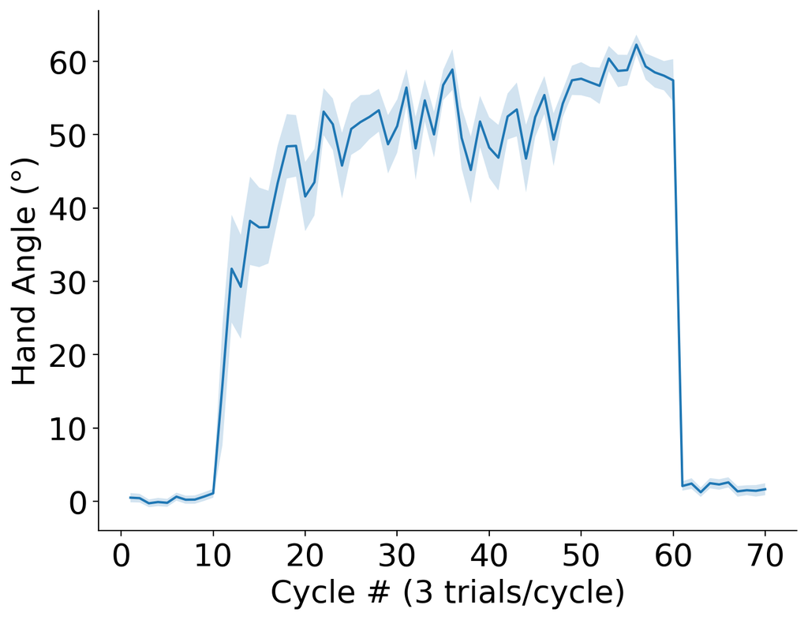

```python
from scipy.stats import sem, bootstrap

def avg_every_3(df, col, start=0, end=210, med=False):
    # get the average HAs across participants for each cycle (every 3 trials)
    # for most data set withoutt generalization block (or with the g block removed), there are 210 trials
    # (30 baseline + 150 perturbation + 30 washout)
    # one can specify the start and end point trial, but has to be multiple of 3

    df = df.copy()
    means = []  # track means for each cycle
    sems = []   # track sems for each cycle
    df[col] = df[col].apply(lambda lst:lst[start:end])

    for t in np.arange(0, len(df[col].iloc[0]), 3): # every 3 trials = each cycle
        angles = []

        # get the all angles from all participants for the current cycle, take and mean and sem
        for subj in range(df.shape[0]):
            angles.extend(df[col].iloc[subj][t:t+3])

        if not med:
            if col=='RT' or 'RT (b)':
                mean = np.mean(angles)
                std_dev = np.std(angles)

                # Define a threshold for identifying outliers (e.g., 3 standard deviations from the mean)
                threshold = 5

                # Filter the list to exclude outliers based on z-scores
                angles = [x for x in angles if abs(x - mean) < threshold * std_dev]
            means.append(np.mean(angles))
            sems.append(sem(angles))
        else:
            means.append(np.median(angles))
            sems.append(bootstrap((angles, ), np.median, n_resamples=1000, confidence_level=0.95).standard_error)

    return np.array(means), np.array(sems)

plt.figure(figsize=(8, 6), dpi=200)
HA_mean, HA_sd = avg_every_3(dat, col='Modified Hand Angle (b)')

plt.plot(np.arange(1, len(HA_mean)+1), HA_mean)
plt.fill_between(np.arange(1, len(HA_mean)+1), HA_mean-HA_sd, HA_mean+HA_sd, alpha=0.2)

plt.xlabel('Cycle # (3 trials/cycle)', fontsize=20)
plt.ylabel('Hand Angle (°)', fontsize=20)

plt.xticks(fontsize=20)
plt.yticks(fontsize=20)
plt.gca().spines['top'].set_linewidth(0)  # Remove top spine
plt.gca().spines['right'].set_linewidth(0)  # Remove right spine
```

Now, we want to better understand participants’ exploration patterns during early adaptation (trials 30–60) and whether they form specific hypotheses about the perturbation, beyond what the average hand angle in the learning curve reveals. So we are going to go ahead and fit the Von mises Mixture Model on the early adaptation data to see where the hand angles peak.

Let's take a look of the distribution first!

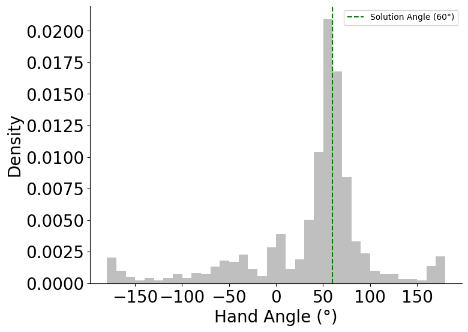

```python
exp_data_deg = extract_data_for_fitting(dat)
exp_data_rad = np.deg2rad(exp_data_deg)

plt.figure(figsize=(8, 6))
plt.hist(exp_data_deg, bins=36, density=True, color='gray', alpha=0.5)
plt.axvline(x=60, color='green', linestyle='--', label='Solution Angle (60°)')

plt.xticks(fontsize=20)
plt.yticks(fontsize=20)
plt.gca().spines['top'].set_linewidth(0)  # Remove top spine
plt.gca().spines['right'].set_linewidth(0)  # Remove right spine

plt.xlabel('Hand Angle (°)', fontsize=20)
plt.ylabel('Density', fontsize=20)
plt.legend()
plt.show()
```

As you can see, by visual inspection, there are around 3-4 peaks for this data set. Now, let's fit the model on this data.

```
Fitting model with 2 components...
Fitting model with 3 components...
Fitting model with 4 components...
Fitting model with 5 components...

Model Comparison Results:
------------------------------------------------------------
Components  BIC            Log-likelihood
------------------------------------------------------------
3           2721.84        -1332.46
4           2726.00        -1323.87
5           2740.79        -1320.59
2           2781.53        -1372.98
```

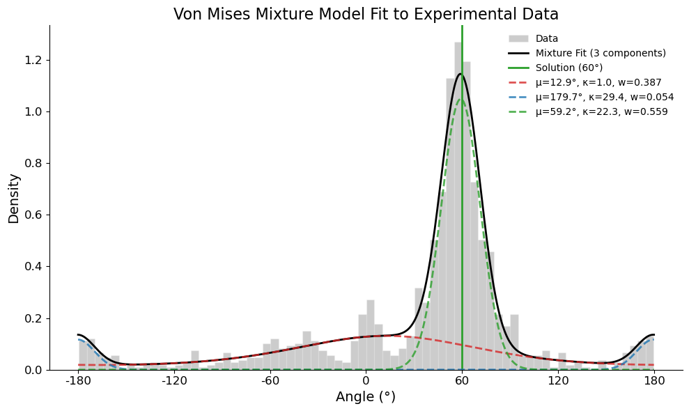

```
Best Model Parameters:
Number of components: 3
BIC score: 2721.84

Component parameters:
  Component 1: μ=12.9°, κ=1.0, weight=0.387
  Component 2: μ=179.7°, κ=29.4, weight=0.054
  Component 3: μ=59.2°, κ=22.3, weight=0.559
```

```python
# Fit the model
model = VonMisesMixture(min_components=2, max_components=5, use_uniform_noise=False)
model.fit(exp_data_rad)

# Plot the results
model.plot(exp_data_rad, solution_angle=60, title="Von Mises Mixture Model Fit to Experimental Data")

# Get and print the parameters
params = model.get_parameters()
print("\nBest Model Parameters:")
print(f"Number of components: {params['n_components']}")
print(f"BIC score: {params['bic']:.2f}")
print("\nComponent parameters:")
for i in range(params['n_components']):
    print(f"  Component {i+1}: μ={params['means_deg'][i]:.1f}°, κ={params['kappas'][i]:.1f}, weight={params['weights'][i]:.3f}")
```

The Bayesian Information Criterion (BIC) helps us determine the optimal number of components for our mixture model. Let's examine how the BIC changes as we vary the number of components:

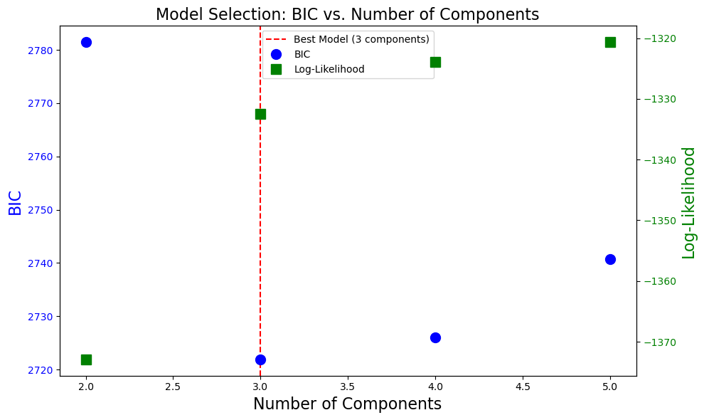

```python
def plot_bic_comparison(model):
    """Plot the BIC values for different numbers of components."""
    if not model.all_results:
        raise ValueError("Model has not been fitted yet. Call fit() first.")

    # Extract results
    components = [result['n_components'] for result in model.all_results]
    bic_values = [result['bic'] for result in model.all_results]
    log_likelihoods = [result['log_likelihood'] for result in model.all_results]

    # Plot
    fig, ax1 = plt.subplots(figsize=(10, 6))

    # Highlight the best model
    best_idx = np.argmin(bic_values)
    ax1.axvline(components[best_idx], linestyle='--', color='red',
            markersize=10, label=f'Best Model ({components[best_idx]} components)')

    # Plot BIC
    ax1.plot(components, bic_values, 'o', markersize=10, color='blue', label='BIC')
    ax1.set_xlabel('Number of Components', fontsize=16)
    ax1.set_ylabel('BIC', color='blue', fontsize=16)
    ax1.tick_params(axis='y', labelcolor='blue')


    # Add log-likelihood on a second y-axis
    ax2 = ax1.twinx()
    ax2.plot(components, log_likelihoods, 's', color='green', markersize=10, label='Log-Likelihood')
    ax2.set_ylabel('Log-Likelihood', color='green', fontsize=16)
    ax2.tick_params(axis='y', labelcolor='green')

    # Combine legends
    lines1, labels1 = ax1.get_legend_handles_labels()
    lines2, labels2 = ax2.get_legend_handles_labels()
    ax1.legend(lines1 + lines2, labels1 + labels2, loc='upper center')

    plt.title('Model Selection: BIC vs. Number of Components', fontsize=16)
    plt.tight_layout()
    plt.show()

# Plot BIC comparison
plot_bic_comparison(model)
```

## Analysis and Interpretation

When interpreting von Mises mixture models, it's essential to understand what the different parameters tell us about the underlying data structure. Here's a guide to interpreting the key parameters and model metrics:

### Parameter Interpretation Guide

**Mean (μ)**: This parameter indicates the central direction of a strategy or pattern. Components with means within 5-10° of the solution angle likely represent successful learning strategies. Components with means approximately 180° away from the target may indicate a mirror strategy (participants aiming in exactly the opposite direction). Multiple clustered means appearing close together may indicate uncertainty around a single strategy.

**Concentration (κ)**: This parameter indicates how precise or consistent a strategy is. A small κ value (in the example which is 1) suggests very diffuse behavior with high variability, typically seen in random exploration. Values between 2 and 10 indicate moderate consistency in applying a strategy. Values greater than 10 suggest a highly consistent strategy, while values exceeding 20 represent extremely focused behavior that might be algorithmic or deterministic in nature.

**Weight (w)**: This parameter indicates the prevalence of a particular strategy in the data. A weight greater than 0.5 may indicates a dominant strategy that most participants employed. Weights between 0.2 and 0.5 may suggest a common strategy used by a substantial portion of participants. Weights between 0.05 and 0.2 may indicate secondary strategies, while weights below 0.05 may represent noise or outlier patterns that should be interpreted cautiously.

### Model Selection Metrics

**BIC (Bayesian Information Criterion)**: This metric balances model fit and complexity, with lower values being better. When comparing models with different numbers of components, the one with the lowest BIC typically provides the best balance between fitting the data and keeping the model simple.

**Log-Likelihood**: This measures how well the model fits the data, with higher values indicating better fit. When evaluating models, it's important to pay attention to diminishing returns—if adding more components only marginally increases the log-likelihood, the simpler model may be preferable.

**Number of Components**: This represents model complexity. Generally, it's best to choose the smallest number of components that adequately explains the data patterns. When BIC values are close between models with different numbers of components, the simpler model (fewer components) is typically preferred.

In our example, we identified three primary hypotheses participants tested when faced with a 60° rotation:

1. **Gradual Learning (μ ≈ 12.9°, κ ≈ 1.0, w ≈ 0.387)**: This component likely captures early, gradual exploration as people move toward the correct solution. The low κ indicates high variability, which is typical of exploration.
2. **Correct Solution (μ ≈ 59.2°, κ ≈ 22.3, w ≈ 0.559)**: This component reflects those who successfully counteracted the 60° perturbation. The high κ indicates consistent application of this successful strategy.
3. **Opposite Strategy (μ ≈ 179.7°, κ ≈ 29.4, w ≈ 0.054)**: This represents a common "opposite-target" guess strategy. The small weight indicates it's relatively rare.

The fact that the 12.9° component is more diffuse (low κ) highlights individual differences in learning speed and random exploration. In contrast, the 59.2° and 179.7° components show clear, strategic responses with higher κ values.

## Concluding Remarks

The von Mises mixture model provides a powerful way to analyze circular data with multiple modes or strategies. Key advantages include:

1. **Proper handling of the circular nature of angular data**
   - Respects the wrap-around property of circular data
   - Properly calculates distances and means on the circle
2. **Identification of distinct response strategies**
   - Reveals multiple patterns that may be hidden in aggregate statistics
   - Provides quantitative parameters for each strategy (direction, consistency, prevalence)
3. **Robust modeling through statistical tools**
   - Incorporates a uniform noise component for increased model robustness
   - Uses the Bayesian Information Criterion for objective model selection
   - Employs the EM algorithm for reliable parameter estimation
4. **Interpretable parameters with clear meaning**
   - Mean direction (μ) corresponds to specific strategies or hypotheses
   - Concentration (κ) quantifies the consistency of strategy application
   - Weight parameters (w) measure the prevalence of each strategy

I hope you all have fun with this tutorial! :)  
- Yifei Chen (yc1676@princeton.edu)